# Introducing the CEEMID Observatory

Daniel Antal, CFA

9/22/2019

## CEEMID Observatory

The CEEMID Observatory is a high quality integration of several thousand numerical indicators relevant to the promotion, pricing, granting and recommending music. It can be organized into the themes of the proposed European Music Observatory’s pillars.

- Music economy: employment and revenues of the European music business - Diversity: cross-border circulation of repertoire, cross-border mobility, cultural aspects - Society & Training: participation in music education, participation in various form of music, audience indicators - Innovation: our data is high quality data designed to support pricing models, econometric models and machine learning / AI systems.

## Example: Percentage of Internet Users in Rural Population

Let’s have a look a sample indicator and in the next slide review how we got here:

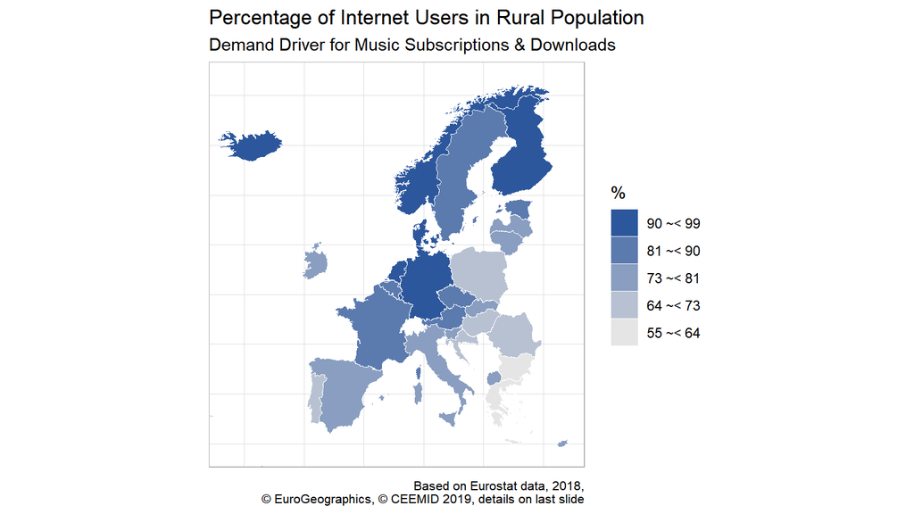

Indicator: internet_use_last_rural_year

## Indicator Summary: Percentage of Internet Users in Rural Population

| Country (group) | actual years | approximated years* | forecasted** | backcasted** | total years |
| --- | --- | --- | --- | --- | --- |
| AT | 15 | 0 | 0 | 0 | 15 |
| BE | 14 | 0 | 0 | 0 | 14 |
| BG | 14 | 1 | 0 | 0 | 15 |
| CH | 2 | 2 | 0 | 0 | 4 |
| CY | 14 | 1 | 0 | 0 | 15 |
| CZ | 15 | 0 | 0 | 0 | 15 |
| DE | 13 | 1 | 0 | 0 | 14 |
| DK | 15 | 0 | 0 | 0 | 15 |
| EA | 15 | 0 | 0 | 0 | 15 |
| EE | 15 | 0 | 0 | 0 | 15 |
| ES | 15 | 0 | 0 | 0 | 15 |
| EU15 | 15 | 0 | 0 | 0 | 15 |
| EU25 | 7 | 0 | 0 | 0 | 7 |
| EU27 | 15 | 0 | 0 | 0 | 15 |
| EU28 | 12 | 0 | 0 | 0 | 12 |
| FI | 14 | 1 | 0 | 0 | 15 |
| FR | 13 | 0 | 0 | 0 | 13 |
| GB | 9 | 0 | 0 | 0 | 9 |
| GR | 13 | 2 | 0 | 0 | 15 |
| HR | 12 | 0 | 0 | 0 | 12 |
| HU | 15 | 0 | 0 | 0 | 15 |
| IE | 13 | 1 | 0 | 0 | 14 |
| IS | 12 | 3 | 0 | 0 | 15 |
| IT | 15 | 0 | 0 | 0 | 15 |
| LT | 15 | 0 | 0 | 0 | 15 |
| LU | 14 | 1 | 0 | 0 | 15 |
| LV | 15 | 0 | 0 | 0 | 15 |
| MK | 1 | 0 | 0 | 0 | 1 |
| MT | 14 | 0 | 0 | 0 | 14 |
| NL | 14 | 0 | 0 | 0 | 14 |
| NO | 14 | 1 | 0 | 0 | 15 |
| PL | 15 | 0 | 0 | 0 | 15 |
| PT | 15 | 0 | 0 | 0 | 15 |
| RO | 13 | 0 | 0 | 0 | 13 |
| SE | 15 | 0 | 0 | 0 | 15 |
| SI | 14 | 1 | 0 | 0 | 15 |
| SK | 15 | 0 | 0 | 0 | 15 |
| XK | 1 | 0 | 0 | 0 | 1 |
| total | 487 | 15 | 0 | 0 | 502 |

Note:  
* Missing values are intrapolated when data is available in the years before and after ** When enough data is present, we extrapolate to years where data is not yet known *** When enough data is present, we backcast to years when statistics were not yet reported or missing.

## How we increased the data quality?

- Reproducible research principle: we always download the freshest data from Eurostat whenever there is an update or revision.
- Tidyness: we process the data according to the Tidy data principle, which makes joining with other (public or private data) possible.

In international comparisons it is ienvitable that some countries are late with reporting there data, or have to revise data points. Therefore international comparative data for the year 2017 is often not yet available in 2019. Many Eurostat data tables are only around 70% complete.

## How we increased the data quantity?

- Intrapolation: whenever there is a missing ‘hole’ in the data we will it with an intrapolation algorithm. For example, if Albania has only data for 2013 and 2015, we take the average of these two years for 2014 for Albania only.
- Extrapolation: when a certain country is reporting late, or the indicator is late, we use the best forecast for its value. We may use linear extrapolation if that is the best model, but we always use the best available forecasting model for the data.
- Backcasting: Often new countries are included, especially in potential member and neighborhood countries such as Montenegro, North Macedonia, Serbia, etc. If only the last few years are available, we backcast the data with the best available model.

## CEEMID Observatory II

The CEEMID Observatory uses the ICET model which is recommended by the Eurostat Statistcal Network ESSnet-Culture. For all pilars of the recommended European Music Observatory we collect:

- Information indicators: where people find information about new song releases
- Communication indicators: with whom people visit concerts
- Enjoyment of music indicators: in hours, in number of events
- Transactions indicators: such as number of tickets, blank CD’s purchased, concerts visited.

## Music Economy - Demand Drivers (Live)

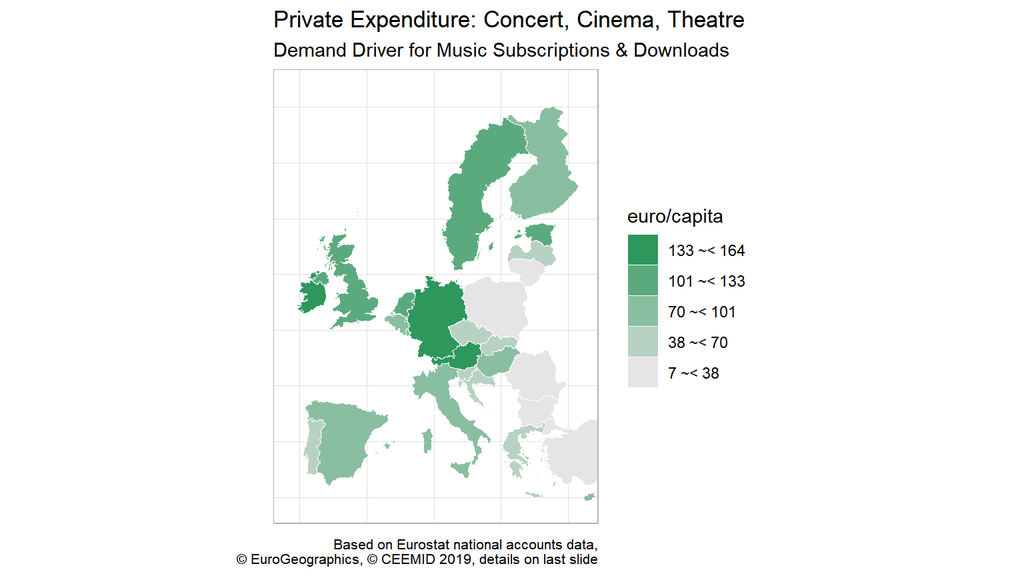

## Music Economy - Demand Drivers (Recorded)

The various drivers of live and recorded music are different, and they work differently in Noric, Western, Eastern and Southern member states.

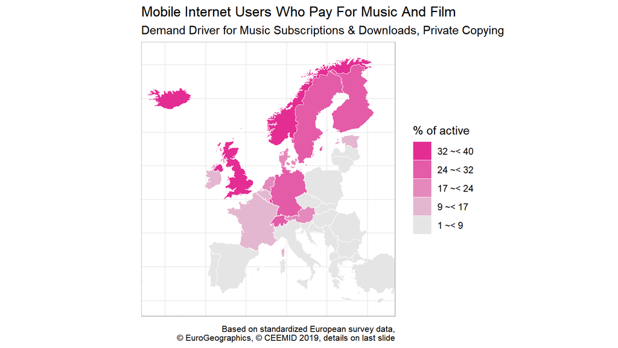

## Music Economy - Specific Live & Licensed Use Drivers (Recorded)

In some cases, Enjoyment and Transactions variables, such as enjoyment hours of music in hotels or foreign visitors to music festivals require special economic & social indicators. This is the case in royalty setting, too.

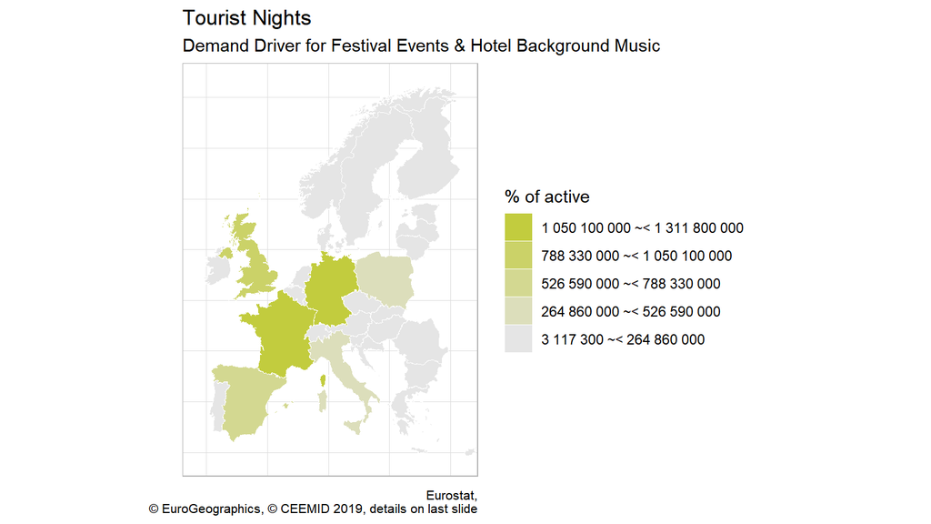